# Ecosystem Service Flood Control | Norway

# Changelog

Changes since version 0:

- first complete version, Magnus Merkle, SSB, 2. September 2025, prepared input data, calculated service flows, met and unmet demand, SU tables, disaggregated by ecosystems and NUTS2 regions. Additionally, this analysis includes a case study for the municipality of Evje & Hornnes.

# Abstract

In this notebook we quantify the ecosystem service of flood control for the Norwegian mainland. Most operations are executed with functions from R packages dplyr and terra. The notebook is created on the basis of the following sources:

- Vallecillo et al. (2019) Ecosystem services accounting Part II Pilot accounts for crop and timber provision, global climate regulation and flood control. European Commission: JRC Technical Reports.
- EC (2023) Guidance note to account for flood control ecosystem service - 1st Draft. Agenda Item 6, Task Force on Ecosystem Accuonting, 28-29 November 2023.
- Immerzeel & Korkou (2024) Evaluation of the INCA-Tool for the purpose of ecosystem services accounting in Norway. EU Grants Project 2022-NO-EGD- Work Package 2. Norwegian Institute for Nature Research

The process is implemented with reference to the work done by Harry Hodgins, Statistics Ireland. Harry has quantified ES flood control for Ireland using R.

# 1. Filepaths and Functions

Just importing and defining a few things here.

```r
# make space
rm(list = ls())
gc()

# packages
library(dplyr)
library(tidyr)
library(terra)
library(sf)
library(osmdata)
library(knitr)
# filepath
dfp<-file.path("C:","Users","muk",
               paste0("OneDrive - Statistisk sentralbyr","\U00E5"),
               "data","INCA")

# functions

# A function to extract levels vectors from factor data stored in rasters
# rst is raster file, lrn is layer name
extr_lvl_from_raster_lyr<-function(rst,lrn){
  if(is.factor(rst[[lrn]])){
    v1 <- as.vector(values(rst[[lrn]]))
    v2 <- as.vector(levels(rst[[lrn]]))[[1]]
    v3 <- v2$value[v1]
    return(v3)
  } else {
    return(as.vector(values(rst[[lrn]])))
  }
}
```

# 2. Runoff Retention

## 2.1 Introduction

The first step in the quantification of flood control is to create a raster map of potential runoff retention. This map is a key input to the ensuing steps. We start from the Norwegian land cover map and a European Hydrological Soil Charateristics map. Each combination of land cover and soil characteristic is associated to a Curve Number (CN) value - an index of infiltration/runoff. The resulting curve number raster map is then further refined using various inputs.

## 2.2 Create CN Map

### 2.2.1 LCM

Read in and plot our land cover categories.

```r
# read Norway Grunnkart (this is our reference LCM) ----------------------------
lcm<-terra::rast(file.path(dfp,"Norway_files","Grunnkart","Grunnkart_OT.tif"))
unique(lcm)
```

```
##                                                                            Class
## 1                                           Bebyggelse/samferdsel (uspesifisert)
## 2                                                   Sammenhengende boligområder
## 3                Sammenhengende områder for tjenesteyting, handel \nog industri
## 4                                                         Oppdelte boligområder
## 5                                                                  Infrastruktur
## 6                                  Vei- og jernbanenettverk med tilhørende mark
## 7                                                                  Havneområder
## 8                                                                     Flyplasser
## 9                                                            Annen infrastruktur
## 10                                                     Mineralutvinningsområder
## 11                                                                        Parker
## 12                                                Sports- og rekreasjonsområder
## 13                                                      Gravlunder, kirkegårder
## 14                                                  Jordbruksmark (uspesifisert)
```

[output cut: 16 more lines]

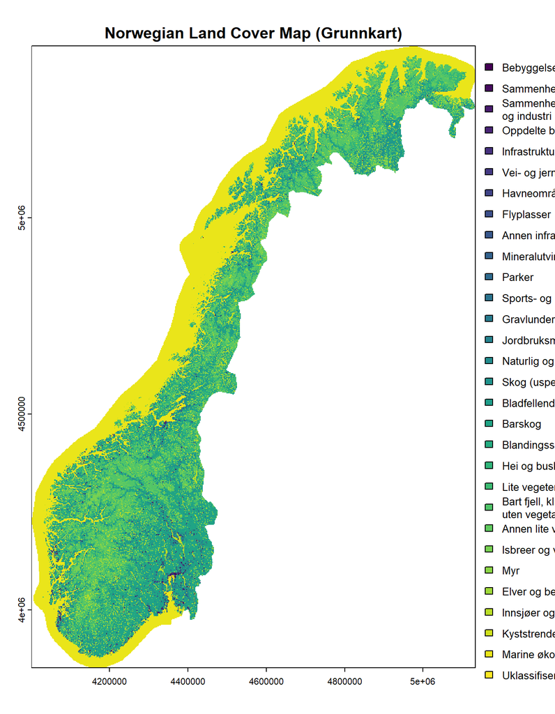

```r
terra::plot(lcm, main="Norwegian Land Cover Map (Grunnkart)")
```

Now the fact of the matter is that the categories used in the Norwegian LCM do not perfectly correspond to the categories used in the curve number table. Therefore we first need to translate the Norwegian categories into the system used in the CORINE data.

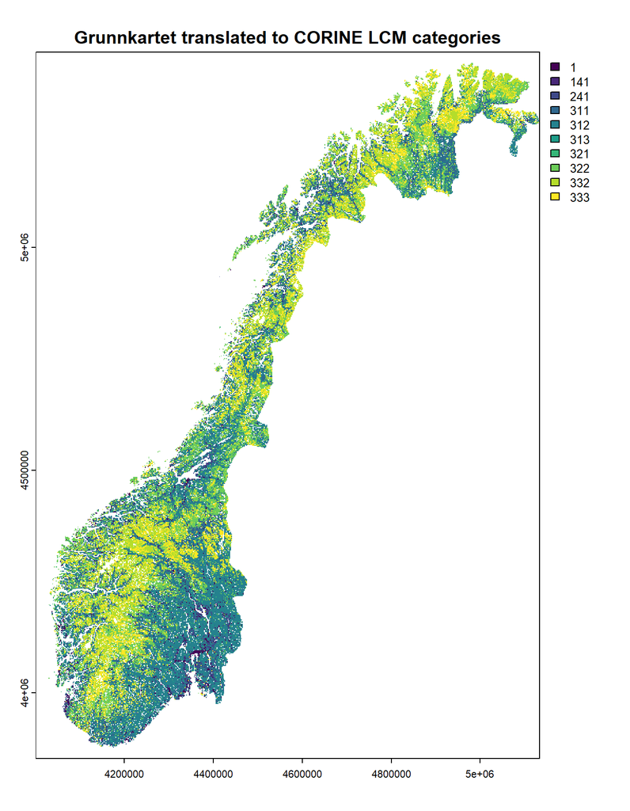

```r
# make a numeric version of the lcm --------------------------------------------
lcm2<-lcm
activeCat(lcm2) <- "Value"
lcm2<-as.numeric(lcm2)


# read in grunnkart lookup -----------------------------------------------------
lcm_idf<-read.csv(file.path(dfp,"Norway_files","Grunnkart",
                            "Lookup_grunnkart.csv"))

# read in curve number table ---------------------------------------------------
cn_idf<-read.csv(file.path(dfp,"version_2_2","inca_input_floodcontrol",
                           "Lookup_tables",
                           "curve_number_per_landcover_soil.csv"))

# adjust lcm to feature official CORINE categories -----------------------------
# (otherwise our CN lookup table does not fit)
# I create this concordance using the following sources
# https://land.copernicus.eu/content/corine-land-cover-nomenclature-guidelines/html/
# https://nibio.brage.unit.no/nibio-xmlui/bitstream/handle/11250/3120510/NIBIO_RAPPORT_2024_10_28.pdf?sequence=1&isAllowed=y
lcm_idf['CN_cover_id']<-NA
lcm_idf$CN_cover_id[lcm_idf$landcover_id %in%
                      c(100,111,112,121,130,131,132,133,134,135,142,152)] <- 1
lcm_idf$CN_cover_id[lcm_idf$landcover_id == 141] <- 141
lcm_idf$CN_cover_id[lcm_idf$landcover_id == 200] <- 241
lcm_idf$CN_cover_id[lcm_idf$landcover_id == 310] <- 231
lcm_idf$CN_cover_id[lcm_idf$landcover_id == 320] <- 321
lcm_idf$CN_cover_id[lcm_idf$landcover_id == 400] <- 312
lcm_idf$CN_cover_id[lcm_idf$landcover_id == 410] <- 311
lcm_idf$CN_cover_id[lcm_idf$landcover_id == 420] <- 312
lcm_idf$CN_cover_id[lcm_idf$landcover_id == 440] <- 313
lcm_idf$CN_cover_id[lcm_idf$landcover_id == 520] <- 322
lcm_idf$CN_cover_id[lcm_idf$landcover_id == 600] <- 333
lcm_idf$CN_cover_id[lcm_idf$landcover_id == 611] <- 332
lcm_idf$CN_cover_id[lcm_idf$landcover_id == 623] <- 333
lcm_idf$CN_cover_id[lcm_idf$landcover_id == 631] <- NA
lcm_idf$CN_cover_id[lcm_idf$landcover_id == 720] <- 322
lcm_idf$CN_cover_id[lcm_idf$landcover_id == 810] <- NA
lcm_idf$CN_cover_id[lcm_idf$landcover_id == 910] <- NA
lcm_idf$CN_cover_id[lcm_idf$landcover_id == 1100] <- NA
lcm_idf$CN_cover_id[lcm_idf$landcover_id == 1200] <- NA

# and then we add the last category that is not available (uklassifisert)
lcm_idf <- rbind(lcm_idf,c(NA,9900,"unclassified","uklassifisert",NA))
lcm_idf$landcover_id <- as.numeric(lcm_idf$landcover_id)

# make a new lcm that features the CN_cover_id
lcm3 <- terra::subst(lcm2,lcm_idf$landcover_id,lcm_idf$CN_cover_id)
terra::plot(lcm3, main="Grunnkartet translated to CORINE LCM categories")
```

```r
# make a numeric version of this
lcm4 <- rast(ext(lcm3),resolution=res(lcm3),crs=crs(lcm3))
values(lcm4)<-as.numeric(extr_lvl_from_raster_lyr(lcm3,"value"))
```

So this is our reference land cover map. Moving on.

### 2.2.2 Hydrological Soil Type

```r
# read hydrological soil type map ----------------------------------------------
soils<-terra::rast(file.path(dfp,"version_2_2","inca_input_floodcontrol",
                             "Hydrological_soil_type_map",
                             "hydro_soilgroup_INCA_EPSG3035.tif"))
# mm comment: only four categories seems a bit coarse...
# mm comment: the soils data is masked in a weird way in the north of Norway.
# I think we should really use something better here.
```

Ok so a few adjustments are required here. First we need to mask it to our reference LCM. Then we need to figure out what we do with the part in northern Norway that is missing in the data.

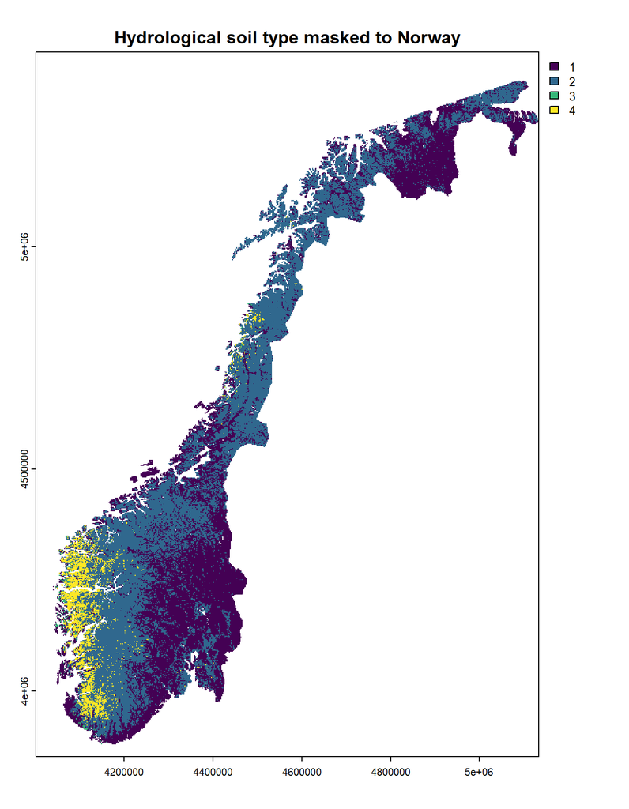

```r
# first crop and mask soils ----------------------------------------------------
soils<-crop(soils,lcm)
soils<-mask(soils,lcm)
terra::plot(soils, main="Hydrological soil type masked to Norway")
```

```r
# mm comment: so here you see again how the soil map is weirdly masked in the
# north. comes from the input data. To be sorted out later
```

Here is my suggested quick fix (which should be revisited later): We just define the missing data cells as hydrological soil type 2. This is the most common hydrological soil type in Norway.

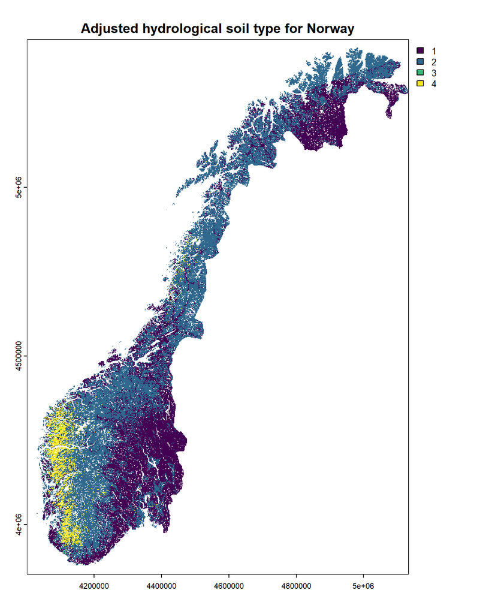

```r
soils[is.na(soils)]<-2
soils<-mask(soils,lcm3)
terra::plot(soils, main="Adjusted hydrological soil type for Norway")
```

Ok this is better. The map has a quite a few holes, and this comes from cells that have no CN number in tghe lookup table. Revisit later. The categories in question are: 9900 (uklassifisert), 1200 (marine økosystemer (uspesifisert)), 1100 (Kyststrender dyner og våtmark (uspesifisert)), 910 (Innsjøer og dammer), 810 (Elver og bekker), and 631 (Isbreer og varige snøfonner). We might want to consider making a modification later so that we assume some CN for some of these categories. Could for example check how Switzerland treats their glacier land cover. Assuming no CN implies that these cells cannot provide flood control.

### 2.2.3 Curve Number

So this is now basically a lookup exercise. My approach is to vectorise the rasters, then run the merge process, then rasterise again. There are probably more efficient ways to do this, but this one is simple and it seems to work.

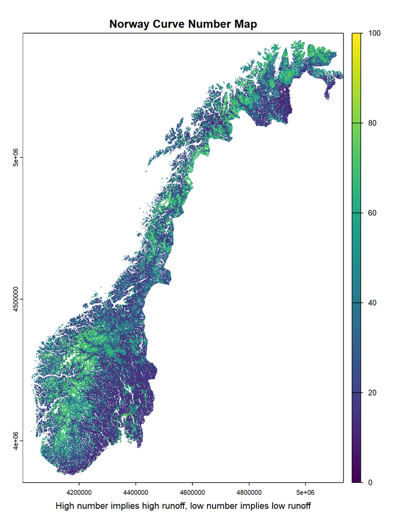

```r
# extract data vectors
lcmv <-extr_lvl_from_raster_lyr(lcm3,"value")
soilsv <-extr_lvl_from_raster_lyr(soils,"hydro_soilgroup_INCA_EPSG3035")
# put into a dataframe
dfc<-as.data.frame(matrix(NA,nrow=length(lcmv),ncol=2))
colnames(dfc)<-c("lcmd","soilsd")
dfc$lcmd <- as.numeric(lcmv)
dfc$soilsd <- soilsv
# join with CN lookup table
dfc <- dfc %>% left_join(cn_idf,by = join_by(lcmd == landcover_id,soilsd == Soil))
# then make a raster from the vector
cnm <- rast(ext(lcm3),resolution=res(lcm3),crs=crs(lcm3))
values(cnm)<-dfc$CN
# plot result
terra::plot(cnm, range=c(0,100), main="Norway Curve Number Map", sub="High number implies high runoff, low number implies low runoff")
```

```r
# clean up ---------------------------------------------------------------------
rm(dfc,soils,lcmv,soilsv)
gc()
```

## 2.3 Modify CN Map

### 2.3.1 Imperviousness Correction

We use the INCA default impervious density map.

```r
imp <- terra::rast(file.path(dfp,"version_2_2","inca_input_floodcontrol",
                             "Impervious_density_map",
                             "IMD_2018_100m_eu_03035_V2_0_INCA_100m_EPSG3035.tif"))
```

Mask to our reference raster.

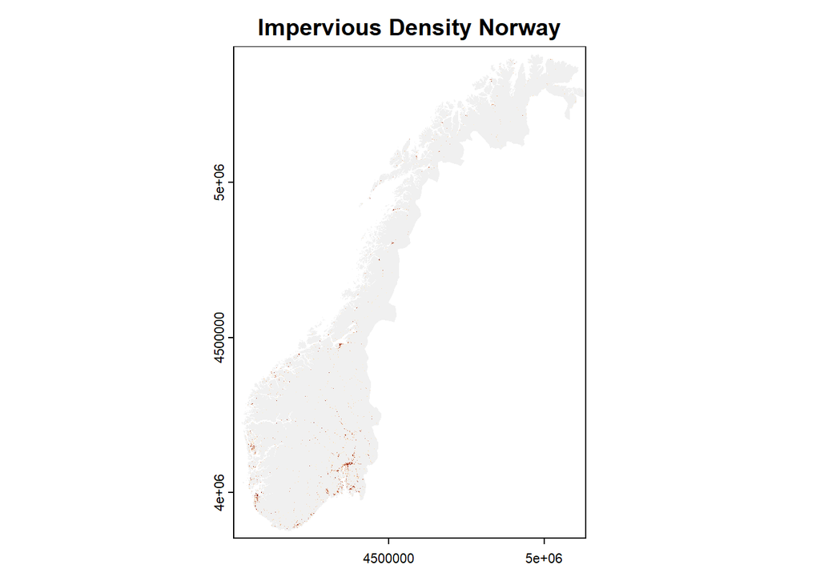

```r
# first crop and mask to Norway
imp<-crop(imp,lcm)
imp<-mask(imp,lcm)
terra::plot(imp, main="Impervious Density Norway")
```

For this operation we do not need to vectorise first. The equation comes from the guidance note, corrected by Harry. Can just do this straight with the rasters. And then plot the result.

```r
cnmi <- 98*(imp/100) + (1-(imp/100))*cnm
# make a stack
cnm1 <- c(cnm,cnmi)
names(cnm1)<-c("CN","CN Adjusted 1")
```

Differences are visible mostly in cities. Not a big difference. Here zooming in on Oslo.

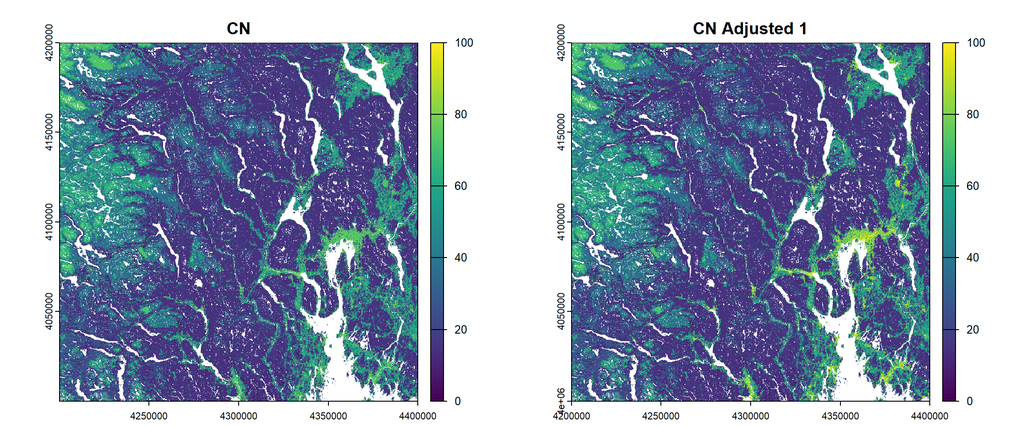

```r
terra::plot(cnm1,range=c(0,100),ext = c(4200000,4400000,4000000,4200000))
```

```r
# clean up
rm(imp,cnmi)
gc()
```

### 2.3.2 Slope Correction

We use the INCA default DEM and Slope maps, cropped and masked to Norway.

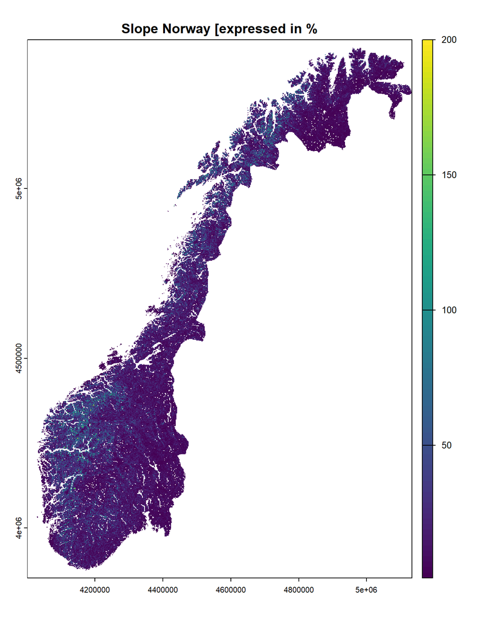

```r
slop <- terra::rast(file.path(dfp,"version_2_2","inca_input_floodcontrol",
                             "DEM_and_Slope_maps",
                             "dt1_slope_INCA_EPSG3035_100m_Byte.tif"))
slop<-crop(slop,lcm)
slop<-mask(slop,lcm)
plot(slop, main="Slope Norway [expressed in %")
```

Our data provides slopes in percent. The equation stated in the guidance note based on Huang et al 2016 requires slopes as ratio (ratio = percent/100). Zero slope is NA in the data, so I first turn all NA to zero before running the process. Then apply the formula as stated in the guidance note. And then plot to see what difference the operation makes.

```r
slop[is.na(slop)]<-0
cnma <- cnm1[['CN Adjusted 1']] * ((322.79 + (15.63*slop/100))/((slop/100)+323.52))
cnm2<-c(cnm1,cnma)
names(cnm2)<-c("CN","CN Adjusted 1","CN Adjusted 1_2")
```

The difference is really small. We need to zoom in quite a lot to see anything. Here for example, somewhere close to Åndalsnes.

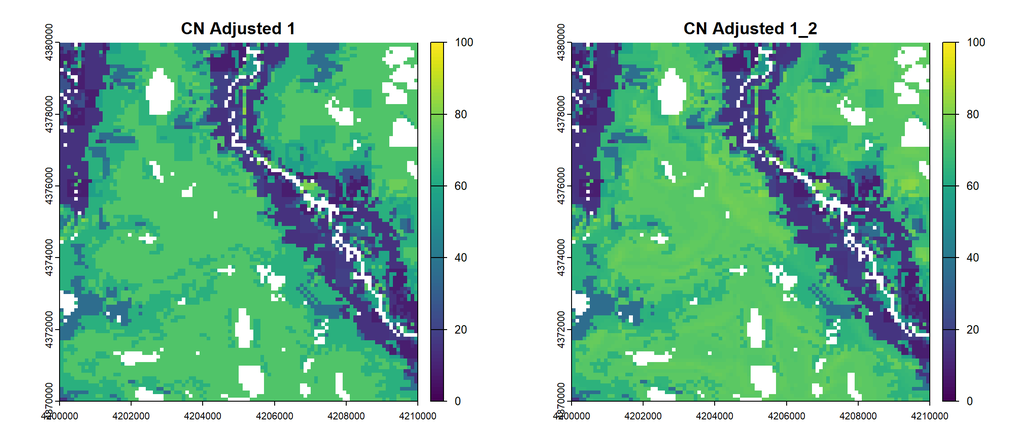

```r
plot(cnm2[[c(2,3)]],range=c(0,100),ext = c(4200000,4210000,4370000,4380000))
```

```r
rm(slop,cnma,cnm1)
gc()
```

### 2.3.3 Riparian Zone Correction

Then the riparian zones. Again we use INCA default data for this adjustment.

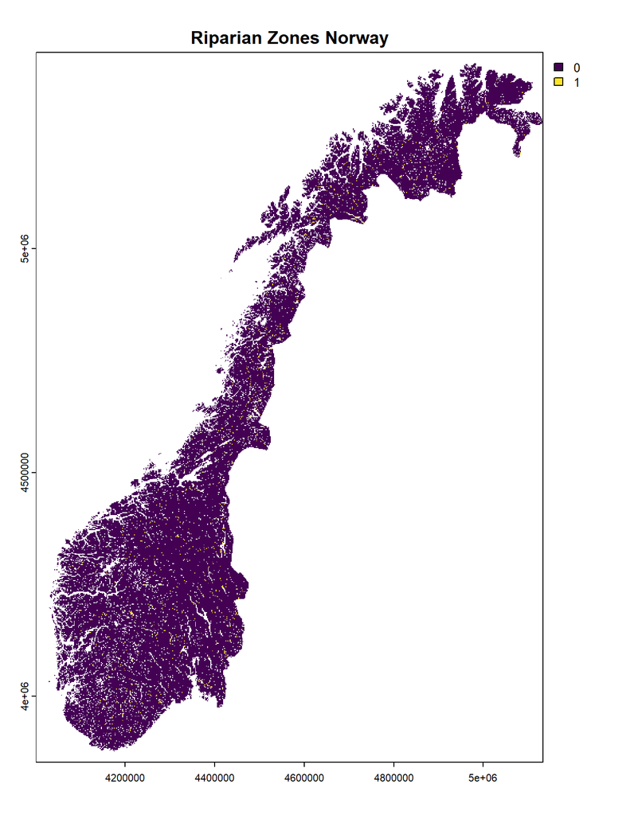

```r
# import data
rip <- terra::rast(file.path(dfp,"version_2_2","inca_input_floodcontrol",
                              "Riparian_zones_map",
                              "RiparianZonesEU_INCA_EPSG3035.tif"))


# first crop and mask to Norway
rip<-crop(rip,lcm)
rip<-mask(rip,lcm)
# to make it better visible
rip[is.na(rip) & !is.na(lcm3)]<-0

plot(rip,main="Riparian Zones Norway")
```

Ok and then the process.

```r
# define relevant landcover categories as per guidance note
lcm_idf['rip_relevant']<-0

relevant_codes <- c(244,311,312,313,321,322,323,324,411,412,421,422,423)
# mm note: most of those do not exist in our Grunnkart in Norway...
# the only ones in Norway are category 3 (forest)
lcm_idf$rip_relevant[lcm_idf$CN_cover_id %in% relevant_codes]<-1

# now for those cells where we are in a relevant riparian zone we will attribute
# the lowest possible cn number for the respective land cover.

# get vector of rip
ripv <- extr_lvl_from_raster_lyr(rip,"RiparianZonesEU_INCA_EPSG3035")
# get vector of lcm
lcmv <- extr_lvl_from_raster_lyr(lcm3,"value")
lcmv <-as.numeric(lcmv)

# get vector of CN
cnv <- extr_lvl_from_raster_lyr(cnm2,"CN Adjusted 1_2")

# relevant rip lcmv
dfc<-as.data.frame(matrix(NA,ncol=3,nrow=length(lcmv)))
colnames(dfc)<-c("lcm","rip","relevant")

#first the land cover data
dfc$lcm <- lcmv
#then the riparian zone data
dfc$rip <- ripv
# then the relevant cells
dfc$relevant[dfc$rip==1 & dfc$lcm %in% relevant_codes] <- 1
# then find the lowest possible CN value for each cell
dfc <- dfc %>%
  left_join(cn_idf %>% filter(Soil==1) %>% select(-Soil),by = join_by(lcm == landcover_id)) %>%
  rename(CN1 = CN)
#clean up
rm(rip,ripv,lcmv)
dfc <- dfc %>% select(-c(lcm,rip))
gc()
#then get the cn number for each cell
dfc['CNIS'] <- cnv
rm(cnv)
#adjusted CN is the lowest CN
dfc['CNISR'] <- dfc$CN1
gc()
# apart from in rip-irrelevant cells, where it is the old CN value
dfc$CNISR[is.na(dfc$relevant)] <- dfc$CNIS[is.na(dfc$relevant)]
gc()

# then make a new raster
cnma <- rast(ext(lcm3),resolution=res(lcm3),crs=crs(lcm3))
values(cnma)<-dfc$CNISR
names(cnma)<-c("CN Adjusted 1_2_3")

# then stack with our other
cnm2 <- c(cnm2,cnma)

# clean up
rm(dfc,relevant_codes,cnma)
gc()
```

Again we don’t see so much on the large picture. Let’s zoom in on where Svelle (Øyeren/Glomma) flows into Nitelva (passing Lillestrøm).

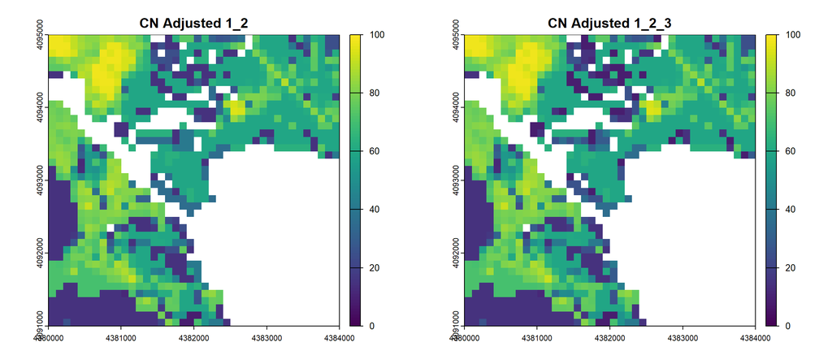

```r
plot(cnm2[[c(3,4)]],range=c(0,100),ext = c(4380000,4384000,4091000,4095000))
```

That was it for adjustments. The exercise might be much more precise if we could get hold of more detailed/specific data for Norway.

## 2.4 Final Runoff Retention Map

We just need to reverse the scale for this. So that a high number implies that water is absorbed, and a low number implies that water is not absorbed. This is now the main map from which we derive flood control service provision.

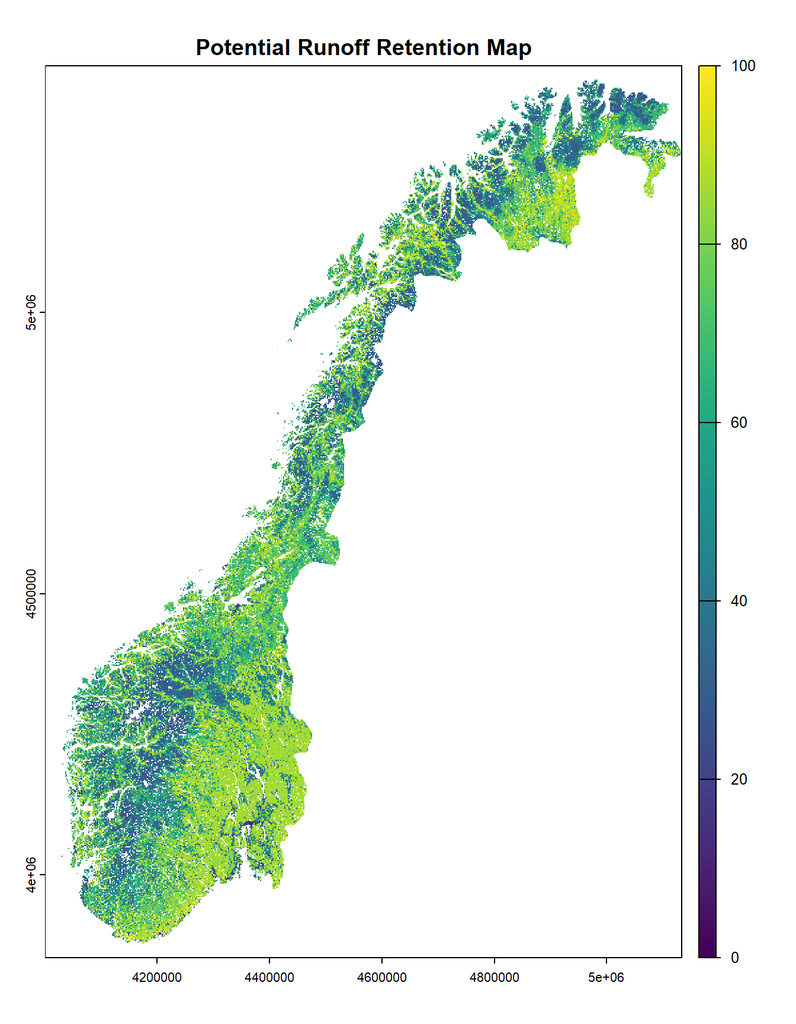

```r
max_value <- as.numeric(global(cnm2[[4]],fun = "max", na.rm=T))

potm <- max_value - cnm2[[4]]
names(potm)<-"Pot_Runuff_Retention"

plot(potm, range=c(0,100),main = "Potential Runoff Retention Map")
```

```r
rm(max_value)
```

Let’s have a more detailed look at our case municipality Evje and Hornnes at this point. I add a layer of streets from Open Street Map to this for easier orientation.

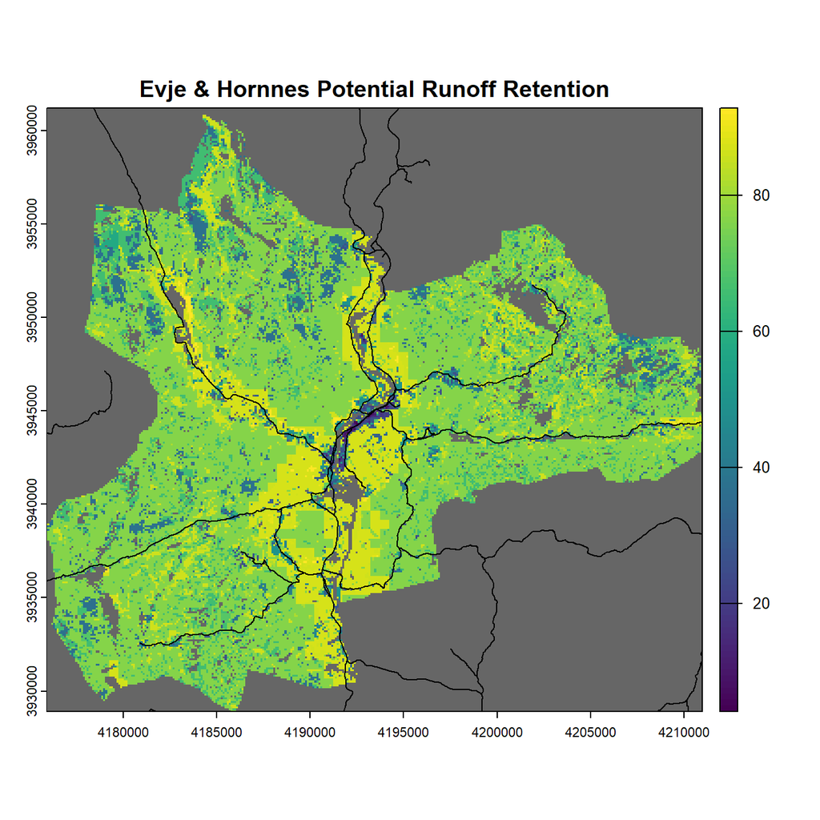

```r
###
ehs<-terra::vect(file.path(dfp,"Norway_files","Evje","evje_formatted.shp"))
eh_potm<-crop(potm,ehs,mask=T)
eh_potm_w84 <- project(eh_potm, "EPSG:4326")
roads <- eh_potm_w84 %>%
  sf::st_bbox() %>%
  osmdata::opq() %>%
  osmdata::add_osm_feature(key="highway",value = c("primary", "secondary", "tertiary", "trunk", "motorway")) %>%
  osmdata_sf()
roads_t <- roads$osm_lines %>%
  terra::vect() %>%
  terra::project(potm)
par(mar = c(0, 0, 0, 0))
plot(eh_potm,colNA="grey40",main = "Evje & Hornnes Potential Runoff Retention")
plot(roads_t,add=T)
```

```r
rm(eh_potm,eh_potm_w84,roads)
```

# 3. Service Providing Areas (SPA)

So now based on our potential runoff retention map we define our service providing areas (SPA). There are three different ones, depending on whether the areas are located on urban/artificial land, agricultural land, or natural land. SP areas are binary, so 1/0. In order to define them, we use runoff retention thresholds, one for each parent land category. Harry at Statistics Ireland came up with their own thresholds, calculated the same way as the EU guidance note suggests. For our version I have first tried to use the thresholds that the guidance note suggests for Europe (27 for artificial land, 52 for agricultural land, 61 for natural land), but then found that these may not be so applicable for Norway. One problem was, for example, that none of the Norwegian agricultural land could be classified as flood control service providing area, simply because the runoff retention threshold of 52 is too high (there is no agricultural patch in Norway that exceeds this threshold).

I therefore calculate Norway specific thresholds using the approach that the guidance note suggests. However, I think this should be revisited. Here are the thresholds

```r
## first on artificial
artif_id<-c(1,141)
spam_artif_am <- rast(ext(lcm3),resolution=res(lcm3),crs=crs(lcm3))
spam_artif_am[[1]]<-0
spam_artif_am[is.na(lcm3)]<-NA
for(i in 1:length(artif_id)){
  spam_artif_am[lcm4 == artif_id[i]]<-mean(potm[lcm4 == artif_id[i]],na.rm=T) + sd(potm[lcm4 == artif_id[i]],na.rm=T)
}
spa_tld_artif <- mean(spam_artif_am[lcm4 %in% artif_id],na.rm=T)

## then on agricultural
agric_id<-c(241,231)
spam_agric_am <- rast(ext(lcm3),resolution=res(lcm3),crs=crs(lcm3))
spam_agric_am[[1]]<-0
spam_agric_am[is.na(lcm3)]<-NA
for(i in 1:length(agric_id)){
  spam_agric_am[lcm4 == agric_id[i]]<-mean(potm[lcm4 == agric_id[i]],na.rm=T) + sd(potm[lcm4 == agric_id[i]],na.rm=T)
}
spa_tld_agric <- mean(spam_agric_am[lcm4 %in% agric_id],na.rm=T)

## then on natural
natur_id<-c(321,312,311,313,322,333,332)
spam_natur_am <- rast(ext(lcm3),resolution=res(lcm3),crs=crs(lcm3))
spam_natur_am[[1]]<-0
spam_natur_am[is.na(lcm3)]<-NA
for(i in 1:length(natur_id)){
  spam_natur_am[lcm4 == natur_id[i]]<-mean(potm[lcm4 == natur_id[i]],na.rm=T) - sd(potm[lcm4 == natur_id[i]],na.rm=T)
}
spa_tld_natur <- mean(spam_natur_am[lcm4 %in% natur_id],na.rm=T)

## clean up
rm(spam_artif_am,spam_agric_am,spam_natur_am)
gc()
```

```r
print(paste("Artificial tld:",spa_tld_artif))
```

```
## [1] "Artificial tld: 30.8893698069349"
```

```r
print(paste("Agricultural tld:",spa_tld_agric))
```

```
## [1] "Agricultural tld: 48.8282508850098"
```

```r
print(paste("Natural tld:",spa_tld_natur))
```

```
## [1] "Natural tld: 61.3397302555812"
```

Now given our thresholds we make a stack of maps for the SPAs

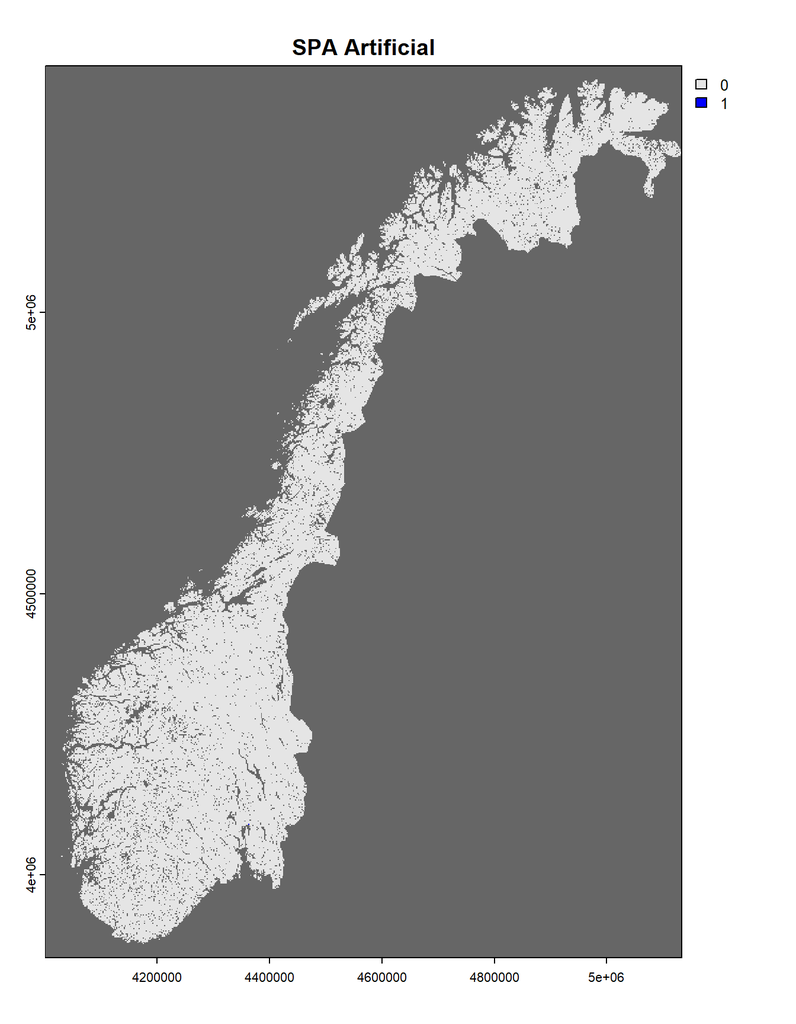

```r
spam_artif<-rast(ext(lcm3),resolution=res(lcm3),crs=crs(lcm3))
spam_artif[[1]]<-0
spam_artif[is.na(lcm3)]<-NA
spam_artif[lcm4 %in% artif_id & potm >= spa_tld_artif] <-1

spam_agric<-rast(ext(lcm3),resolution=res(lcm3),crs=crs(lcm3))
spam_agric[[1]]<-0
spam_agric[is.na(lcm3)]<-NA
spam_agric[lcm4 %in% agric_id & potm >= spa_tld_agric] <-1

spam_natur<-rast(ext(lcm3),resolution=res(lcm3),crs=crs(lcm3))
spam_natur[[1]]<-0
spam_natur[is.na(lcm3)]<-NA
spam_natur[lcm4 %in% natur_id & potm >= spa_tld_natur] <-1

spam <-c(spam_artif,spam_agric,spam_natur)
names(spam)<-c("SPA Artificial","SPA Agricultural", "SPA Natural")
ccspam<-data.frame(value=c(0,1),col=c("grey90","blue"))
plot(spam[[1]],col=ccspam,colNA="grey40",main = "SPA Artificial")
```

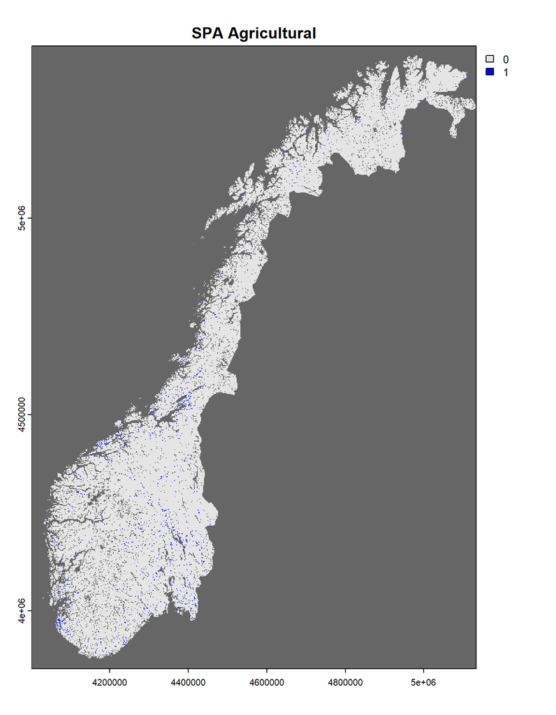

```r
plot(spam[[2]],col=ccspam,colNA="grey40",main = "SPA Agricultural")
```

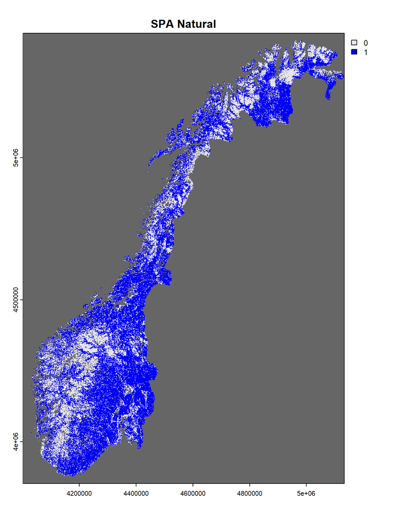

```r
plot(spam[[3]],col=ccspam,colNA="grey40",main = "SPA Natural")
```

```r
rm(ccspam,spam_artif,spam_agric,spam_natur)
```

And then let’s have a dive into our case Evje and Hornnes again. Just to see sevice-providing areas around there.

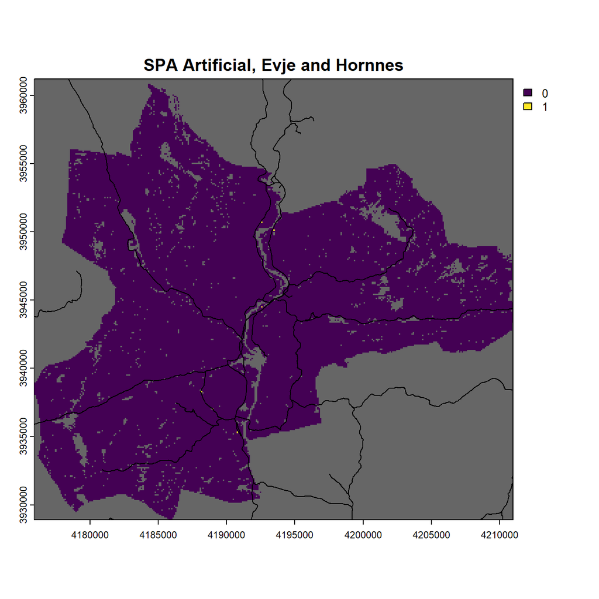

```r
plot(spam[[1]] %>% crop(ehs,mask=T),colNA="grey40",main="SPA Artificial, Evje and Hornnes")
plot(roads_t,add=T)
```

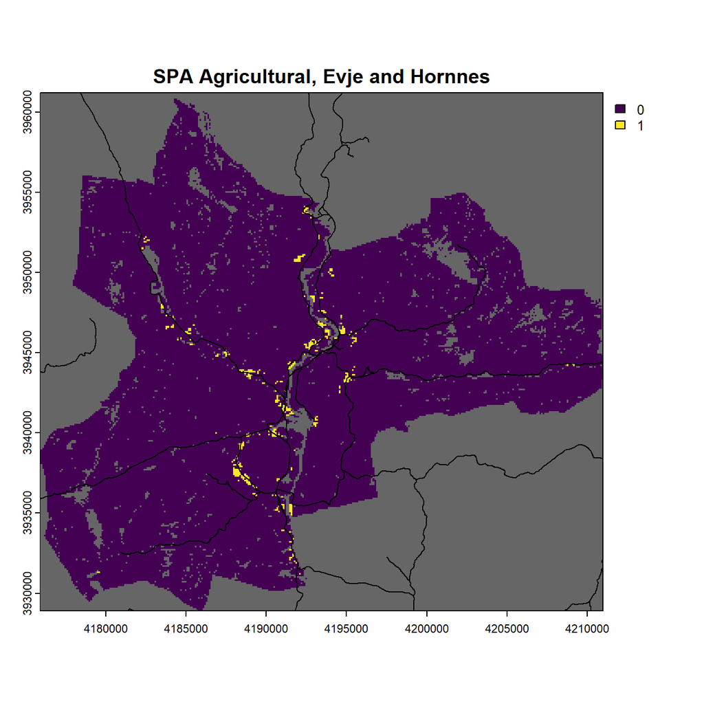

```r
plot(spam[[2]] %>% crop(ehs,mask=T),colNA="grey40",main="SPA Agricultural, Evje and Hornnes")
plot(roads_t,add=T)
```

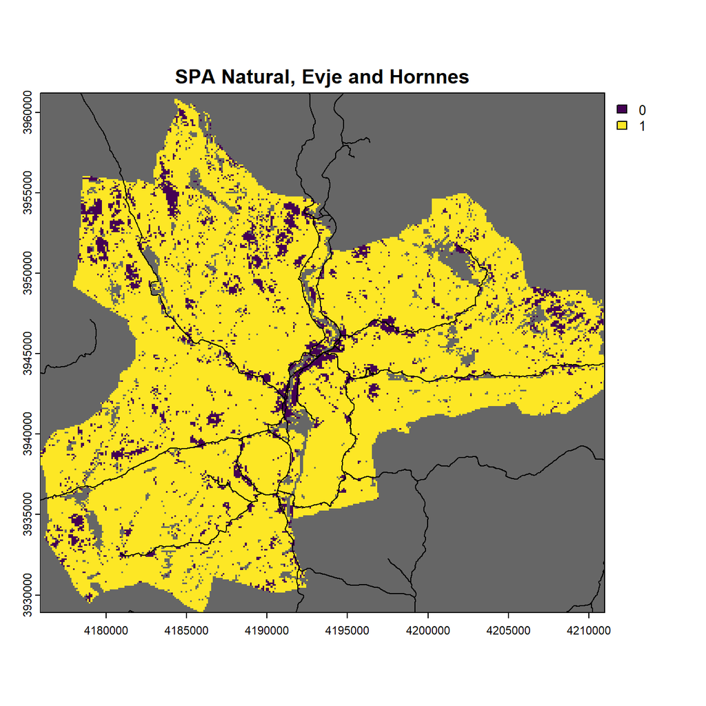

```r
plot(spam[[3]] %>% crop(ehs,mask=T),colNA="grey40",main="SPA Natural, Evje and Hornnes")
plot(roads_t,add=T)
```

# 4. Service Demanding Areas (SDA)

SDAs are service demanding areas. These are defined as economic assets located in floodplains. Formally: total spatial extent of economic assets that could be potentiall affected by a 1 in 500 years flood. Can also run this on the basis of a 1 in 100 years flood. Harry (Statistics Ireland) used 1 in a 1000 years flood. We identify SDAs seperately for agricultural land and for artificial land. Second possibility: total amount of population inhabiting in SDA (Harry does not do this, but we can). So first, we start reading in the data and making it fit to our reference map.

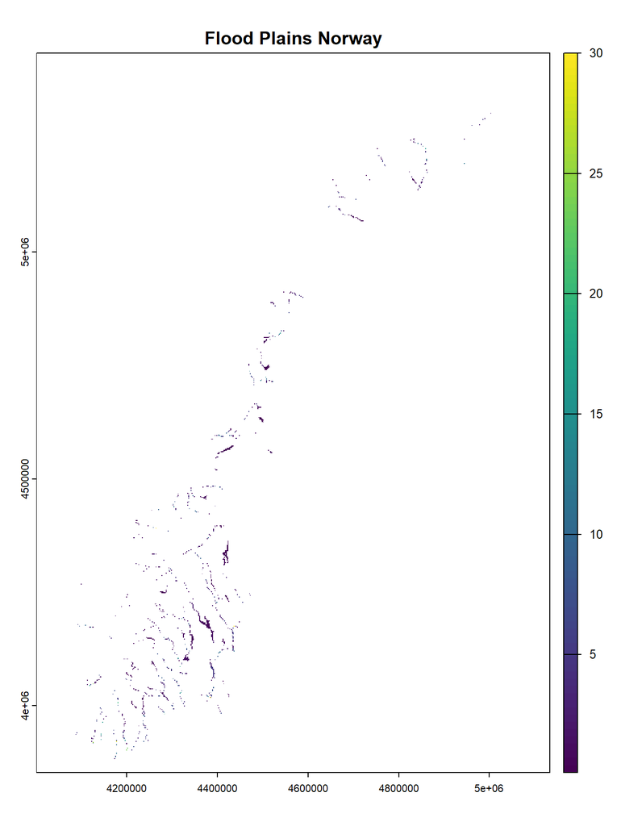

```r
# population
popr<-rast(file.path(dfp,"population","Mollweide","GHS_POP_E2020_GLOBE_R2023A_54009_100_V1_0.tif"))
popr<-crop(popr,ext(250000,
                    2000000,
                    6600000,
                    8000000) # 8700000 if svalbard included
                    )
popr <- terra::project(popr,lcm,mask=T)

# flood
flood <- terra::rast(file.path(dfp,"version_2_2","inca_input_floodcontrol",
                             "Flood_plains",
                             "floodMapEU_rp500y.tif"))
flood <- project(flood,crs(lcm))
flood<-crop(flood,lcm)
ext(flood)<-align(ext(flood),lcm)
flood<-mask(flood,lcm)
plot(flood, main = "Flood Plains Norway")
```

Now it is literally just a question of identifying cells in the flood areas. Different levels in the flood map relate to different depths of flood. Let’s just define any number >0 as flood. Could later consider to make it more continuous.

```r
sdam_pop <- rast(ext(lcm3),resolution=res(lcm3),crs=crs(lcm3))
sdam_pop[[1]] <- 0
sdam_pop[is.na(lcm3)]<-NA
sdam_pop[flood >0 & popr>0] <- popr[flood >0 & popr>0]

sdam_artif <- rast(ext(lcm3),resolution=res(lcm3),crs=crs(lcm3))
sdam_artif[[1]] <- 0
sdam_artif[is.na(lcm3)]<-NA
sdam_artif[flood >0 & lcm4 %in% artif_id] <- 1

sdam_agric <- rast(ext(lcm3),resolution=res(lcm3),crs=crs(lcm3))
sdam_agric[[1]] <- 0
sdam_agric[is.na(lcm3)]<-NA
sdam_agric[flood >0 & lcm4 %in% agric_id] <- 1
```

Then let’s plot the results here.

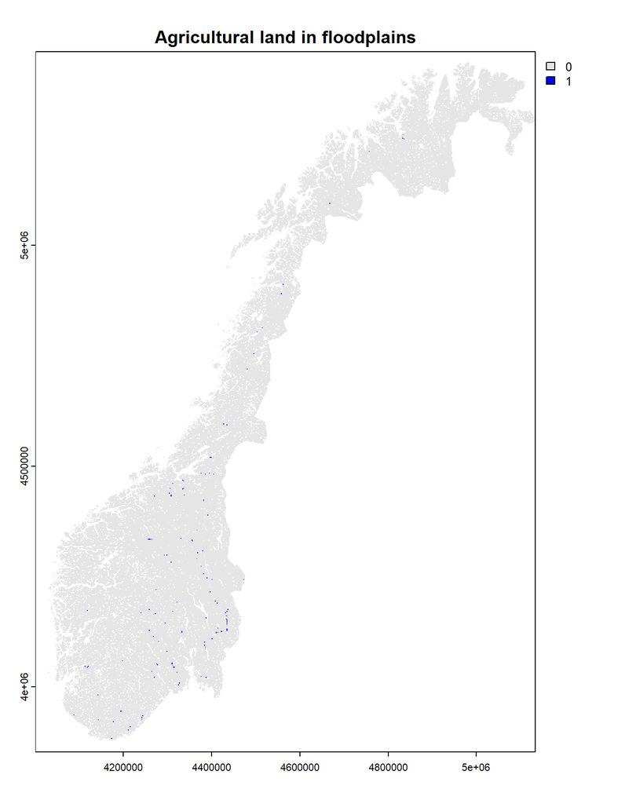

```r
plot(sdam_agric,col=c("grey90","blue"),main = "Agricultural land in floodplains")
```

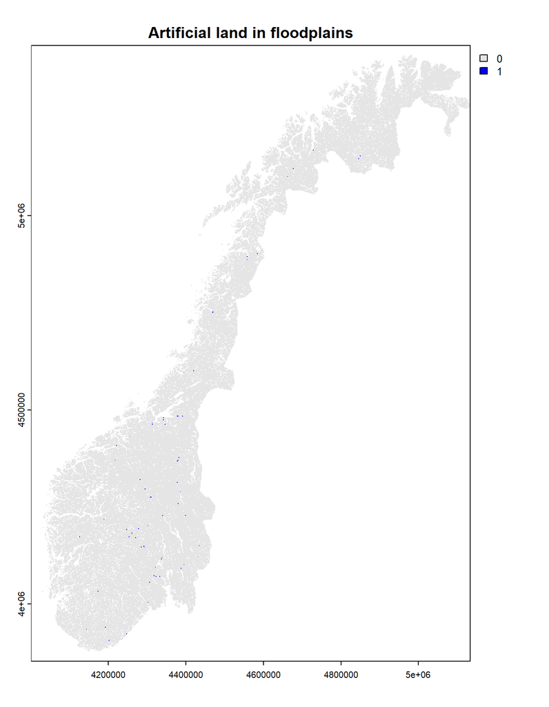

```r
plot(sdam_artif,col=c("grey90","blue"),main = "Artificial land in floodplains")
```

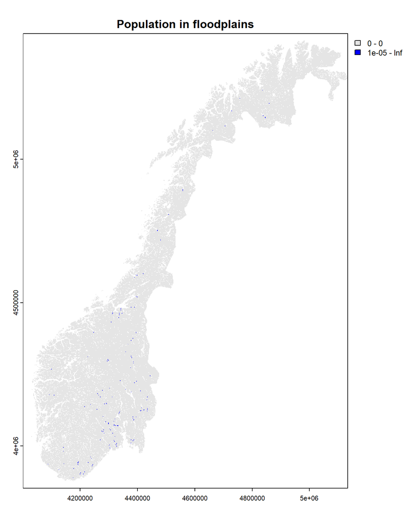

```r
ccsdam<-data.frame(from=c(0,0.00001),to=c(0,Inf),col=c("grey90","blue"))
plot(sdam_pop,col=ccsdam, main = "Population in floodplains")
```

```r
rm(popr,flood,ccsdam)
gc()
```

And then let’s plot service demand for our case study.

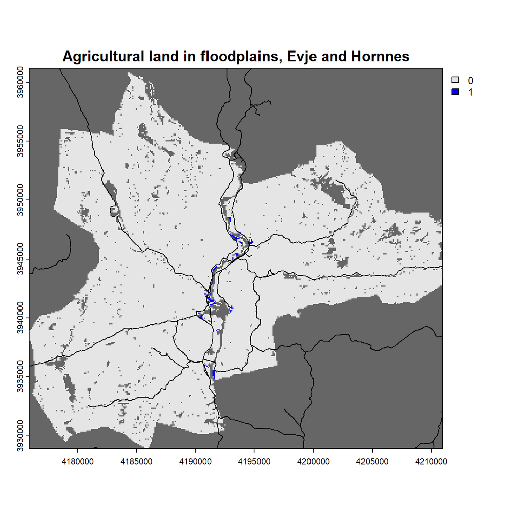

```r
plot(sdam_agric %>% crop(ehs,mask=T),col=c("grey90","blue"),colNA="grey40",
     main="Agricultural land in floodplains, Evje and Hornnes")
plot(roads_t,add=T)
```

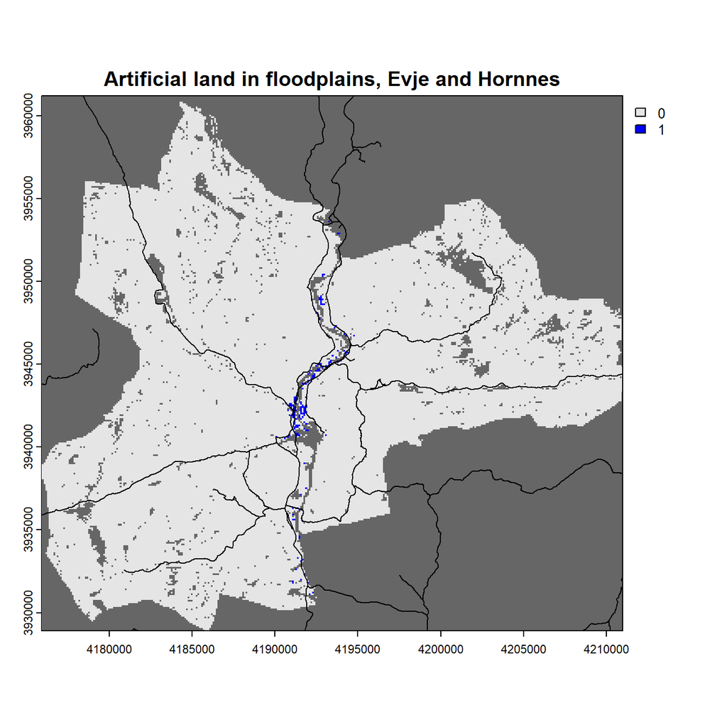

```r
plot(sdam_artif %>% crop(ehs,mask=T),col=c("grey90","blue"),colNA="grey40",
     main="Artificial land in floodplains, Evje and Hornnes")
plot(roads_t,add=T)
```

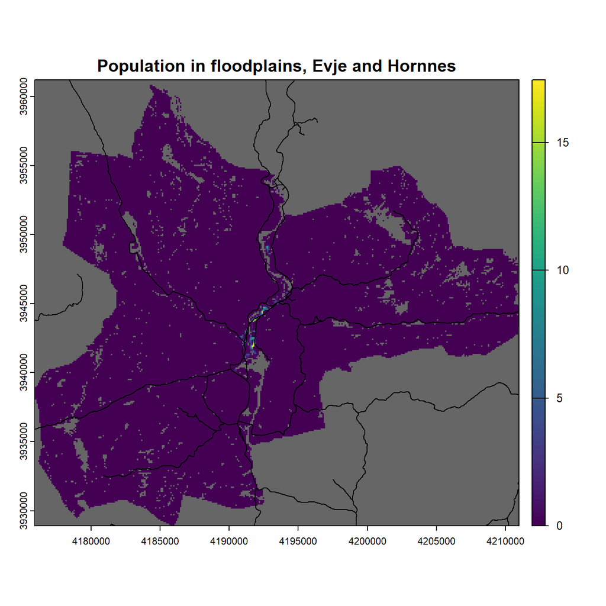

```r
plot(sdam_pop %>% crop(ehs,mask=T),colNA="grey40",
     main="Population in floodplains, Evje and Hornnes")
plot(roads_t,add=T)
```

# 5. Service Flow

Now the service flow is quantified at the level of the SDAs. We calculate it for each SDA gridcell as the ratio of upstream surface area that is covered by SPA. Upstream surface area is the area from which we expect water to flow - so this requires slope information.

NB: the guidance suggests to use all upstream area for this, irrespective of political boundaries. For the time being we limit ourselves to Norway as service providing area, but could include neighbouring countries as well if we want.

The calculation of service flow is straightforward using the built-in functions of R’s terra package. First, we compute the number of upstream cells for each SDA cell. Second, we compute the proportion of these upstream cells that are covered by SPA (of various kind). The service flow is then equal to the ratio of upstream cells covered by SPA over all upstream cells.

Example: If the the ratio is 1, then all upstream cells of a service demanding cell are covered by SPA, hence “flood controlled by the ecosystem”. If the ratio is 0, then none of the upstream cells of a service demanding cell are covered b y SPA, hence “not flood controlled by the ecosystem”.

Important to note here is that when there is no unique flow direction to identify from the slope data, then terra will allocate the flow direction randomly. This is not ideal, but at least we can make terra return unique results by setting seeds for the random sequence generator.

First we import elevation data and compute flow direction and flow accumulation for each grid cell.

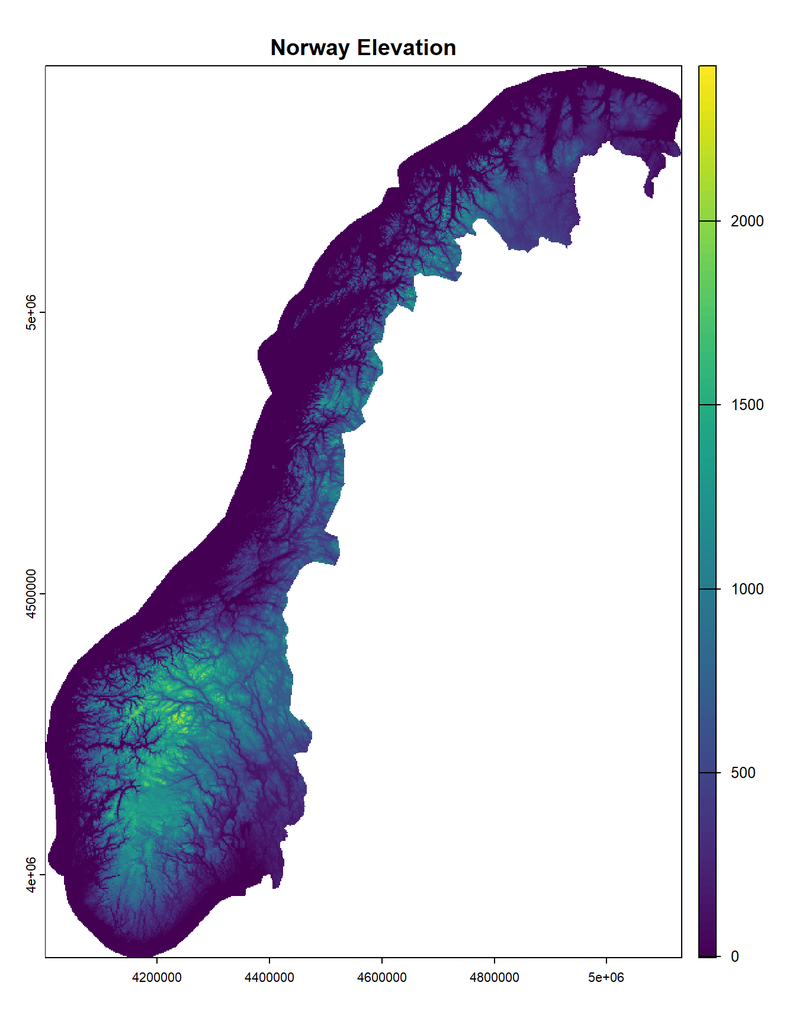

```r
elev <- terra::rast(file.path(dfp,"version_2_2","inca_input_floodcontrol",
                              "DEM_and_Slope_maps",
                              "dt1_dem_INCA_EPSG3035_100m.tif"))
elev<-crop(elev,lcm)
elev<-mask(elev,lcm)
plot(elev,main="Norway Elevation")
```

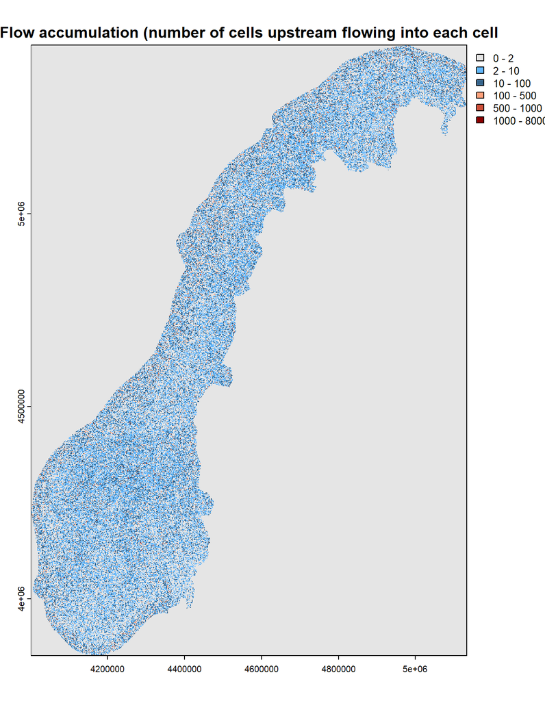

```r
set.seed(2025) # I do this for replicability. Flowdir allocates direction randomly when it is impossible to find a unique direction from the elevation data
flowdir_total <- terra::terrain(elev,v="flowdir")

flow_acc_total <- terra::flowAccumulation((flowdir_total))
plot(flow_acc_total, main = "Flow accumulation (number of cells upstream flowing into each cell",col=data.frame(from=c(0,2,10,100,500,1000),
                    to=c(2,10,100,500,1000,8000),
                    col=c("grey90","steelblue1","steelblue4","lightsalmon","tomato3","red4")))
```

Ok so now we tell terra to remove upstream cells that are SPAs in the calculation of upstream cells. The way I implement this is to use the weight argument in the flowAccummulation function (I have tested the behaviour first on a hypothetical 9x9 grid).

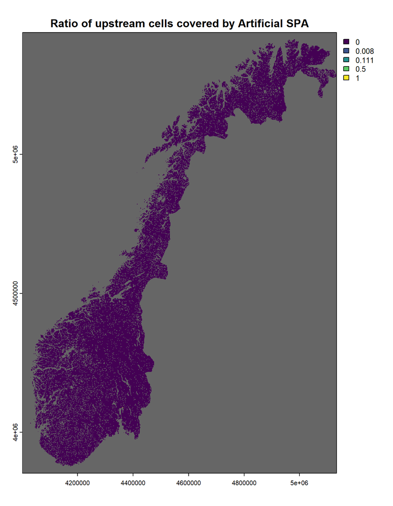

```r
## ratio artificial spa
tmp<-spam[[1]]
# invert 0 and 1
tmp<-tmp+1
tmp[tmp==2]<-0
# then compute restricted flow accummulation
flow_acc_tmp <- terra::flowAccumulation(flowdir_total,tmp)
# then calculate the ratio
ratio_artif<- 1 - flow_acc_tmp/flow_acc_total
# clean up
rm(tmp,flow_acc_tmp)

## ratio agricultural spa
tmp<-spam[[2]]
# invert 0 and 1
tmp<-tmp+1
tmp[tmp==2]<-0
# then compute restricted flow accummulation
flow_acc_tmp <- terra::flowAccumulation(flowdir_total,tmp)
# then calculate the ratio
ratio_agric<- 1 - flow_acc_tmp/flow_acc_total
# clean up
rm(tmp,flow_acc_tmp)

## ratio nature spa
tmp<-spam[[3]]
# invert 0 and 1
tmp<-tmp+1
tmp[tmp==2]<-0
# then compute restricted flow accummulation
flow_acc_tmp <- terra::flowAccumulation(flowdir_total,tmp)
# then calculate the ratio
ratio_natur<- 1 - flow_acc_tmp/flow_acc_total
# clean up
rm(tmp,flow_acc_tmp)

## plot results
plot(ratio_artif,colNA="grey40", main = "Ratio of upstream cells covered by Artificial SPA")
```

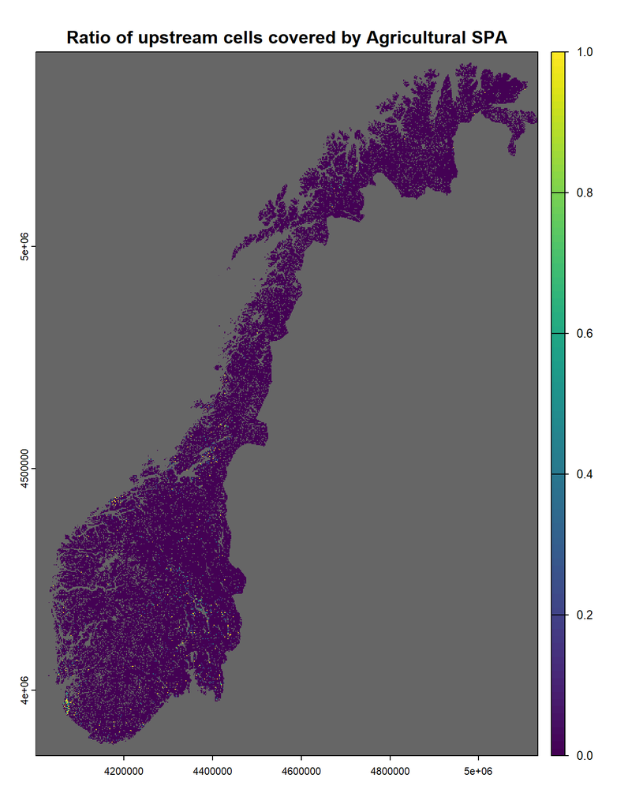

```r
plot(ratio_agric,colNA="grey40",main = "Ratio of upstream cells covered by Agricultural SPA")
```

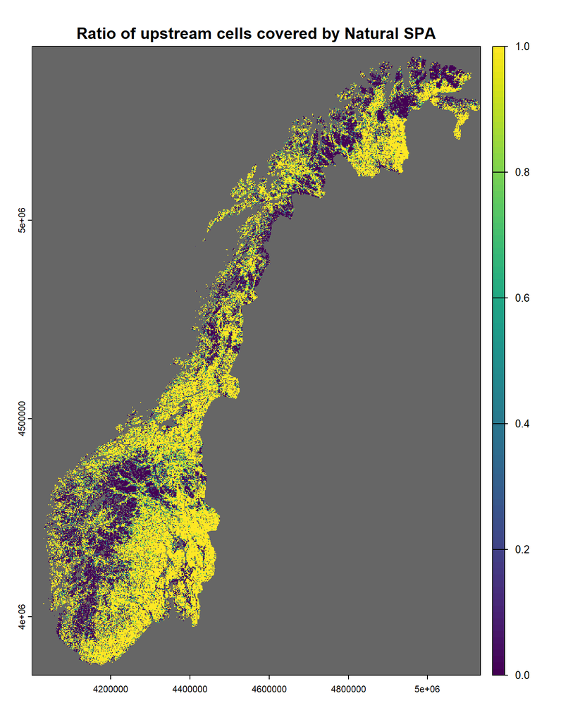

```r
plot(ratio_natur,colNA="grey40",main = "Ratio of upstream cells covered by Natural SPA")
```

```r
gc()
```

Let’s have a look at Evje and Hornnes again to see what it looks like in this specific case.

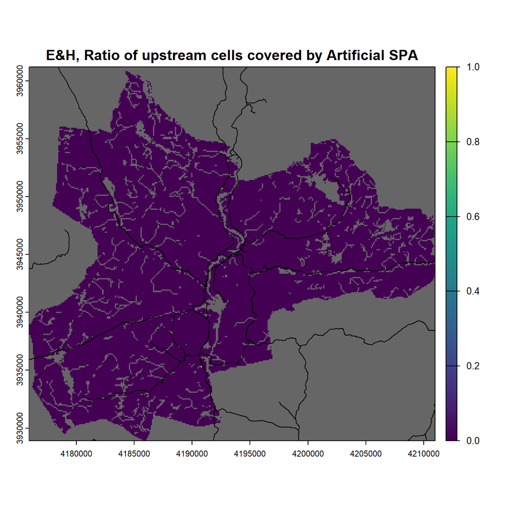

```r
plot(ratio_artif %>% crop(ehs,mask=T),colNA="grey40", main = "E&H, Ratio of upstream cells covered by Artificial SPA")
plot(roads_t,add=T)
```